# Projekt 1 - faza 2

Rafał Cylwa, Dariusz Matlak, Grzegorz Ziajka

12 kwietnia 2016

## Exploration of stations position on a path

First, we create a data frame with paths representation, so for each of visitors we have a number asociated with station that gives us it’s number on a path (or zero if exhibit was not visited):

| visitors | cnk25 | cnk02b | cnk19a | cnk21 | cnk47 | cnk67 | cnk06 | cnk19b | cnk37 |
| --- | --- | --- | --- | --- | --- | --- | --- | --- | --- |
| 1000001 | 1 | 0 | 0 | 0 | 0 | 0 | 0 | 0 | 0 |
| 1000002 | 0 | 1 | 2 | 3 | 4 | 0 | 0 | 0 | 0 |
| 1000003 | 0 | 0 | 4 | 2 | 0 | 1 | 3 | 5 | 6 |
| 1000005 | 0 | 0 | 0 | 0 | 0 | 0 | 0 | 0 | 0 |
| 1000006 | 0 | 0 | 0 | 0 | 0 | 0 | 0 | 0 | 0 |
| 1000008 | 0 | 0 | 0 | 0 | 0 | 0 | 0 | 0 | 0 |
| 1000009 | 0 | 1 | 2 | 0 | 0 | 0 | 0 | 3 | 0 |
| 1000010 | 0 | 0 | 0 | 0 | 0 | 0 | 0 | 0 | 0 |
| 1000011 | 0 | 0 | 6 | 2 | 0 | 0 | 0 | 0 | 0 |
| 1000012 | 0 | 0 | 1 | 0 | 0 | 0 | 0 | 2 | 0 |

For each station we calculate a median of the order on a path (from non-zero values).

| Station_name | Median |
| --- | --- |
| cnk25 | 1 |
| cnk02b | 1 |
| cnk19a | 2 |
| cnk21 | 5 |
| cnk47 | 8 |

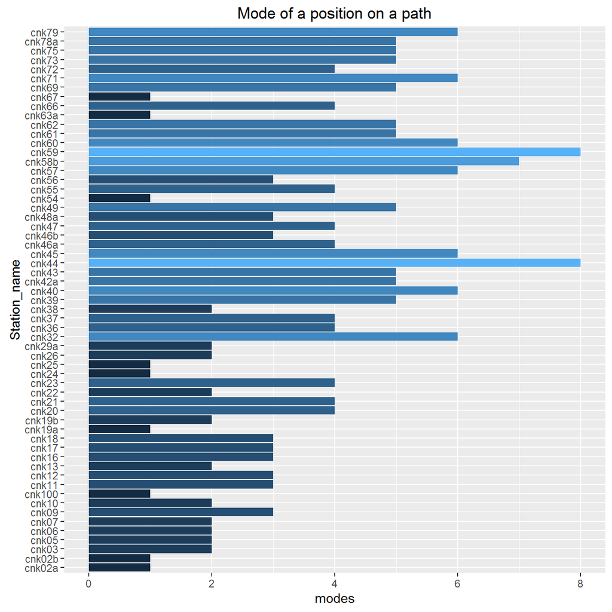

As you can see on a graph above segmentation of exhibits by their most popular position on a paths is clear. We would like to encourage you to compare results with the actual map of stations in CNK.

## Sets of visited exhibits and association rules analysis

Our aim was to analyze paths in dataset smallLogs. By a path we mean ordered collection of stations visited by a single visitor. We have performed the following analyses. At the beginning we clustered paths using two metrics. The first one was simply the number of elements of the symmetric difference of the sets of stations forming the path. The second metric was (up to a multiplicative constant) the Kendall distance of the sequences formed by restriction to common stations on paths. Later we exploited packages *arules*, *arulesSequences* and *arulesViz* in order to find some regularities in the data.

During the clustering we used matrices where the following distances were computed for 4000 different paths. The matrices *setDistMat* and *orderDistMat* contain the necessary distances.

```r
setClustering <- pam(as.dist(setDistMat), k = 80)
typicalSets <- pathList[setClustering$medoids]
typicalSets <- lapply(typicalSets, unname)
typicalSets <- lapply(typicalSets, function(x) unname(sapply(x, InvStationRank)))
typicalSets <- lapply(typicalSets, paste, sep = " ", collapse = " ")
typicalSets <- unlist(typicalSets, recursive = F)
typicalSets <- unname(typicalSets)
typicalSets <- typicalSets[order(nchar(typicalSets), typicalSets)]
typicalSets[1:50]
```

```
##  [1] "cnk10"
##  [2] "cnk16"
##  [3] "cnk17"
##  [4] "cnk18"
##  [5] "cnk22"
##  [6] "cnk24"
##  [7] "cnk39"
##  [8] "cnk54"
##  [9] "cnk56"
## [10] "cnk61"
## [11] "cnk62"
## [12] "cnk75"
## [13] "cnk02a"
## [14] "cnk02b"
## [15] "cnk100"
```

[output cut: 35 more lines]

Medoids of the clusters are usually small sets, whilst clusters are usually their supersets (or almost supersets). In all applications of *cluster::pam* we obtained several singletons including {cnk02b}, {cnk10}, {cnk16}, {cnk17}, {cnk18}, {cnk22}, {cnk24}, {cnk39}, {cnk29a}, {cnk54}, {cnk61}, {cnk62}, {cnk63a} i {cnk78a}, tuples {cnk10, cnk05}, {cnk12, cnk20}, {cnk02a, cnk09}, {cnk02a, cnk16}, {cnk02a, cnk18}, {cnk02a, cnk67}, {cnk13, cnk03}, {cnk22, cnk25}, {cnk78a, cnk23}, triple {cnk11, cnk 16, cnk18} and four elements set {cnk10, cnk16, cnk12, cnk18}.

```r
orderClustering <- pam(as.dist(orderDistMat+0.5*setDistMat), k = 120)
typicalPatterns <- pathList[orderClustering$medoids]
typicalPatterns <- lapply(typicalPatterns, unname)
typicalPatterns <- lapply(typicalPatterns, function(x) unname(sapply(x, InvStationRank)))
typicalPatterns <- lapply(typicalPatterns, paste, sep = " ", collapse = " ")
typicalPatterns <- unlist(typicalPatterns, recursive = F)
typicalPatterns <- unname(typicalPatterns)
typicalPatterns <- typicalPatterns[order(nchar(typicalPatterns), typicalPatterns)]
print(typicalPatterns[c(1,2,3,19,20,21,seq(38,50,1))])
```

```
##  [1] "cnk05"              "cnk10"              "cnk13"
##  [4] "cnk48a"             "cnk78a"             "cnk07 cnk12"
##  [7] "cnk02b cnk09"       "cnk02b cnk18"       "cnk11 cnk46b"
## [10] "cnk46a cnk73"       "cnk58b cnk55"       "cnk78a cnk36"
## [13] "cnk63a cnk42a"      "cnk05 cnk16 cnk37"  "cnk10 cnk16 cnk56"
## [16] "cnk17 cnk16 cnk18"  "cnk18 cnk23 cnk79"  "cnk67 cnk09 cnk11"
## [19] "cnk02a cnk16 cnk12"
```

Because of significant penalization of differences in the order of stations on paths and relatively small penalization of the symmetric difference each cluster contain two types of paths. These are paths which match the medoid pretty well on their common part and those which are nearly disjoint with the medoid, which we can treat as noise. Medoids are the sequences, which (they or their subsequences) appear (maybe with slightly different order of elements) in a significant number of paths in the cluster. In most of cases when we run *pam* we obtain the following sequences: (cnk05, cnk16, cnk37), (cnk02a cnk16 cnk12), (cnk09 cnk78a cnk60), (cnk10 cnk18 cnk78a), (cnk10 cnk16 cnk12 cnk18), (cnk66 cnk20 cnk12 cnk21), (cnk02a cnk16 cnk11 cnk18), (cnk02b cnk10 cnk66 cnk16), (cnk10 cnk21 cnk12 cnk78a) and (cnk16 cnk20 cnk78a cnk40).

We refined the results obtained using packages *arules*, *arulesSequences* i *arulesViz*. We didn’t want to show to many superfluous code, therefore we hid the part of the code responsible for preprocessing. The variable *itemSets* contains a list. Its elements are vectors, whose elements are consecutive stations visited by a CNK guest.

We used *arules::apriori* firstly in order to find frequent sets and then in order to look for association rules. Setting support threshold to 1% (a subset visited at least 1564 times - the total number of guests in analyzed 5 month time interval was 156451) leads to the conclusion that every station and almost every pair of stations is above the threshold. Moreover about 20% of all triples, 3592 quadruples, 843 5-element sets and 16 6-element sets are frequent too.

```r
itemSets <- as(itemSets, "transactions")
frequentStations <- apriori(itemSets, parameter = list(support = 0.01,
                                                       target = "frequent itemsets"))
```

```
## Apriori
##
## Parameter specification:
##  confidence minval smax arem  aval originalSupport support minlen maxlen
##          NA    0.1    1 none FALSE            TRUE    0.01      1     10
##             target   ext
##  frequent itemsets FALSE
##
## Algorithmic control:
##  filter tree heap memopt load sort verbose
##     0.1 TRUE TRUE  FALSE TRUE    2    TRUE
##
## Absolute minimum support count: 1564
##
## set item appearances ...[0 item(s)] done [0.00s].
## set transactions ...[59 item(s), 156451 transaction(s)] done [0.07s].
## sorting and recoding items ... [59 item(s)] done [0.02s].
## creating transaction tree ... done [0.12s].
## checking subsets of size 1 2 3 4 5 6 done [0.72s].
## writing ... [12568 set(s)] done [0.00s].
## creating S4 object  ... done [0.02s].
```

```r
summary(frequentStations)
```

```
## set of 12568 itemsets
##
## most frequent items:
##   cnk16   cnk12  cnk19a   cnk09   cnk10 (Other)
##    2874    2654    2096    2039    1904   29725
##
## element (itemset/transaction) length distribution:sizes
##    1    2    3    4    5    6
##   59 1620 6438 3592  843   16
##
##    Min. 1st Qu.  Median    Mean 3rd Qu.    Max.
##   1.000   3.000   3.000   3.285   4.000   6.000
##
## summary of quality measures:
##     support
##  Min.   :0.01000
##  1st Qu.:0.01108
##  Median :0.01276
##  Mean   :0.01612
##  3rd Qu.:0.01682
##  Max.   :0.37557
##
## includes transaction ID lists: FALSE
##
## mining info:
##      data ntransactions support confidence
##  itemSets        156451    0.01          1
```

```r
frequentStations <- sort(frequentStations, by = "support")
```

The most popular station (with the highest number of visitors) was station cnk19a (“Stress effects - entrance”) odwiedzony przez ponad 37% wszystkich gości oraz eksponaty cnk16 (“Five personality factor”), cnk19b (“Stress efects - exit”), cnk02a (“Brain scan 1”) i cnk18 (“Personality test”) each one visited by more than 20% of all visitors.

```
##    items    support
## 59 {cnk19a} 0.3755681
## 58 {cnk16}  0.2388096
## 53 {cnk19b} 0.2154924
## 51 {cnk02a} 0.2059942
## 56 {cnk18}  0.2030476
## 57 {cnk12}  0.1999092
```

It came as no surprise that the most popular pair of sations was {cnk19a, cnk19b}. Indeed these two locations are just entrance and exit to the same station. More than 21% visited both stations . It is much more than 8.1% being the product of frequences and much less than 37% - the percentage of visitors who checked in in the entrance. The other frequent pairs as we might expect other pairs of popular stations.

```
##      items           support
## 1664 {cnk19a,cnk19b} 0.21015526
## 1679 {cnk16,cnk19a}  0.11094208
## 1677 {cnk12,cnk16}   0.09522470
## 1611 {cnk12,cnk20}   0.08731807
## 1651 {cnk02a,cnk19a} 0.08685147
## 1588 {cnk02b,cnk19a} 0.08579683
```

The most popular six element set was {cnk09, cnk12, cnk16, cnk20, cnk21 cnk66}. It may be surprising that it contains none of cnk18, cnk19a, cnk19b, cnk02a which lead in the popularity ranking.

```
##       items                                   support
## 12554 {cnk09,cnk12,cnk16,cnk20,cnk21,cnk66}   0.01092355
## 12564 {cnk09,cnk10,cnk12,cnk16,cnk20,cnk66}   0.01073819
## 12563 {cnk09,cnk12,cnk16,cnk17,cnk20,cnk66}   0.01050808
## 12556 {cnk09,cnk10,cnk12,cnk16,cnk20,cnk21}   0.01050169
## 12565 {cnk12,cnk16,cnk19a,cnk19b,cnk20,cnk66} 0.01036746
## 12567 {cnk05,cnk09,cnk10,cnk12,cnk16,cnk66}   0.01030355
```

After examination of frequent subsets we observed that the outputs of *apriori* are similar to the results obtained using clustering. We also used *apriori* in mining association.

```r
rules <- apriori(itemSets, parameter = list(support = 0.02, confidence = 0.8,
                                            target = "rules"))
```

```
## Apriori
##
## Parameter specification:
##  confidence minval smax arem  aval originalSupport support minlen maxlen
##         0.8    0.1    1 none FALSE            TRUE    0.02      1     10
##  target   ext
##   rules FALSE
##
## Algorithmic control:
##  filter tree heap memopt load sort verbose
##     0.1 TRUE TRUE  FALSE TRUE    2    TRUE
##
## Absolute minimum support count: 3129
##
## set item appearances ...[0 item(s)] done [0.00s].
## set transactions ...[59 item(s), 156451 transaction(s)] done [0.08s].
## sorting and recoding items ... [59 item(s)] done [0.03s].
## creating transaction tree ... done [0.18s].
## checking subsets of size 1 2 3 4 5 done [0.31s].
## writing ... [87 rule(s)] done [0.00s].
## creating S4 object  ... done [0.04s].
```

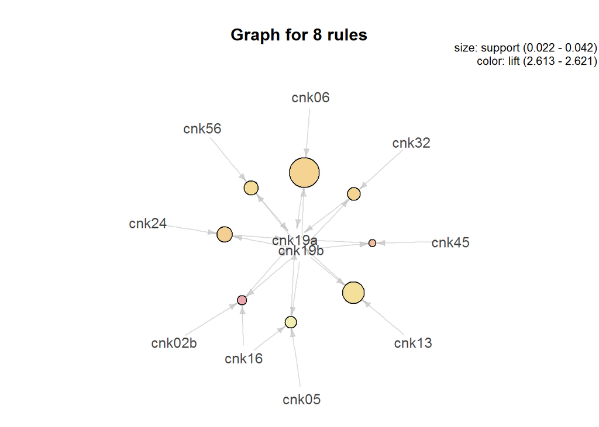

```r
rules <- sort(rules, by = "confidence")[seq(1,8,1),]
plot(rules, method = "graph")
```

```r
inspect(head(rules))
```

```
##    lhs                      rhs      support    confidence lift
## 58 {cnk02b,cnk16,cnk19b} => {cnk19a} 0.02346422 0.9844462  2.621219
## 8  {cnk19b,cnk45}        => {cnk19a} 0.02151472 0.9836353  2.619060
## 6  {cnk19b,cnk24}        => {cnk19a} 0.02927434 0.9828326  2.616923
## 14 {cnk06,cnk19b}        => {cnk19a} 0.04204511 0.9826710  2.616493
## 24 {cnk19b,cnk32}        => {cnk19a} 0.02671763 0.9826046  2.616316
## 11 {cnk19b,cnk56}        => {cnk19a} 0.02801516 0.9822949  2.615491
```

It is evident that the rules, which infer that a guest visited exhibit cnk19a knowing he visited some popular stations reach highest confidence levels. The same is valid for stations cnk12, cnk16 i cnk09.

We looked for rules regarding order of exhibits on a path too. To this end we used *arulesSequences::cspade* algorithm. As before we hid the part of code responsonsible for preprocessing. The object *timedTransactions* contains informations about stations visited by a guest as well as timestamps of his check in.

In most of long paths, stations cnk02a, cnk19a and cnk19b are placed before other frequently visited exhibits. Also there are (found before) subsequences of a sequence (cnk10, cnk16, cnk12, cnk18) which outstand cleary from the others.

```r
minSupp <- 0.005
frequentPaths <- cspade(timedTransactions, parameter = list(support = minSupp))
summary(frequentPaths)
```

```
## set of 34869 sequences with
##
## most frequent items:
##  cnk78a   cnk16   cnk12   cnk18   cnk09 (Other)
##    5856    5720    5515    5391    4217   88610
##
## most frequent elements:
## {cnk78a}  {cnk16}  {cnk12}  {cnk18}  {cnk09}  (Other)
##     5856     5720     5515     5391     4217    88610
##
## element (sequence) size distribution:
## sizes
##     1     2     3     4     5
##    59  2685 18823 13099   203
##
## sequence length distribution:
## lengths
##     1     2     3     4     5
##    59  2685 18823 13099   203
##
## summary of quality measures:
##     support
##  Min.   :0.005010
##  1st Qu.:0.005684
##  Median :0.006832
##  Mean   :0.009025
##  3rd Qu.:0.009307
##  Max.   :0.290136
##
## includes transaction ID lists: FALSE
##
## mining info:
##               data ntransactions nsequences support
##  timedTransactions        445215      50497   0.005
```

```r
frequentPaths <- sort(frequentPaths, by = "support")
twoElementPaths <- frequentPaths[which(size(frequentPaths) == 2)]
twoElementPaths <- sort(twoElementPaths, by = "support")
inspect(twoElementPaths[1:10])
```

```
##     items         support
##   1 <{cnk19a},
##      {cnk19b}> 0.18454562
##   2 <{cnk16},
##      {cnk12}>  0.09271838
##   3 <{cnk16},
##      {cnk18}>  0.09026279
##   4 <{cnk02a},
##      {cnk16}>  0.08687645
##   5 <{cnk16},
##      {cnk78a}> 0.08467830
##   6 <{cnk12},
##      {cnk18}>  0.08178704
##   7 <{cnk10},
##      {cnk16}>  0.08044042
##   8 <{cnk12},
##      {cnk78a}> 0.07863833
##   9 <{cnk16},
##      {cnk20}>  0.07564806
##  10 <{cnk02a},
##      {cnk12}>  0.07406381
##
```

```r
longPaths <- frequentPaths[which(size(frequentPaths) == 5)]
longPaths <- sort(longPaths, by = "support")
inspect(longPaths[1:20])
```

```
##     items          support
##   1 <{cnk19a},
##      {cnk19b},
##      {cnk16},
##      {cnk12},
##      {cnk78a}> 0.007069727
##   2 <{cnk19a},
##      {cnk19b},
##      {cnk16},
##      {cnk12},
##      {cnk18}>  0.006634057
##   3 <{cnk02a},
##      {cnk19a},
##      {cnk19b},
##      {cnk16},
##      {cnk78a}> 0.006138979
##   4 <{cnk19a},
##      {cnk19b},
##      {cnk16},
##      {cnk18},
##      {cnk78a}> 0.006079569
##   5 <{cnk02a},
##      {cnk10},
##      {cnk16},
##      {cnk12},
##      {cnk78a}> 0.005980553
##   6 <{cnk19a},
##      {cnk19b},
##      {cnk16},
##      {cnk12},
##      {cnk20}>  0.005980553
##   7 <{cnk07},
##      {cnk16},
##      {cnk12},
##      {cnk18},
##      {cnk78a}> 0.005960750
##   8 <{cnk05},
##      {cnk16},
##      {cnk12},
##      {cnk78a},
```

[output cut: 47 more lines]

```
##      {cnk19b},
##      {cnk16},
##      {cnk18},
##      {cnk79}>  0.005723112
##  19 <{cnk07},
##      {cnk16},
##      {cnk12},
##      {cnk78a},
##      {cnk79}>  0.005703309
##  20 <{cnk10},
##      {cnk16},
##      {cnk12},
##      {cnk18},
##      {cnk78a}> 0.005703309
##
```

Above we present 20 of most popular five element sequences, please note that most popular pairs found in previous step are subsequences of those longer sequences. It may convince us that there are patterns in paths that CNK guests follow, probably in local sense due to length of identified patterns.

```r
pathRules <- ruleInduction(frequentPaths, confidence = 0.2)
summary(pathRules)
```

```
## set of 21957 sequencerules with
##
## rule size distribution (lhs + rhs)
## sizes
##     2     3     4     5
##   313  9003 12438   203
##
## rule length distribution (lhs + rhs)
## lengths
##     2     3     4     5
##   313  9003 12438   203
##
## summary of quality measures:
##     support           confidence          lift
##  Min.   :0.005010   Min.   :0.2000   Min.   :0.6923
##  1st Qu.:0.005624   1st Qu.:0.2351   1st Qu.:1.6772
##  Median :0.006674   Median :0.2813   Median :1.9075
##  Mean   :0.008546   Mean   :0.2960   Mean   :1.9209
##  3rd Qu.:0.009030   3rd Qu.:0.3405   3rd Qu.:2.1499
##  Max.   :0.184546   Max.   :0.8300   Max.   :4.3691
##
## mining info:
##               data ntransactions nsequences support confidence
##  timedTransactions        445215      50497   0.005        0.2
```

```r
pathRules <- sort(pathRules, by = "lift")
inspect(head(pathRules))
```

```
##    lhs           rhs            support confidence     lift
##  1 <{cnk07},
##     {cnk16},
##     {cnk19a}> => <{cnk19b}> 0.006574648  0.8300000 4.369072
##  2 <{cnk05},
##     {cnk17},
##     {cnk19a}> => <{cnk19b}> 0.005049805  0.8252427 4.344030
##  3 <{cnk05},
##     {cnk16},
##     {cnk19a}> => <{cnk19b}> 0.005406262  0.8222892 4.328483
##  4 <{cnk02b},
##     {cnk07},
##     {cnk19a}> => <{cnk19b}> 0.006436026  0.8207071 4.320155
##  5 <{cnk02b},
##     {cnk17},
##     {cnk19a}> => <{cnk19b}> 0.005267640  0.8184615 4.308334
##  6 <{cnk67},
##     {cnk16},
##     {cnk19a}> => <{cnk19b}> 0.005069608  0.8178914 4.305333
##
```